# HSC Survey Results

# Scots Bay Survey # 4 Results from 21/06/2026

## Survey Details

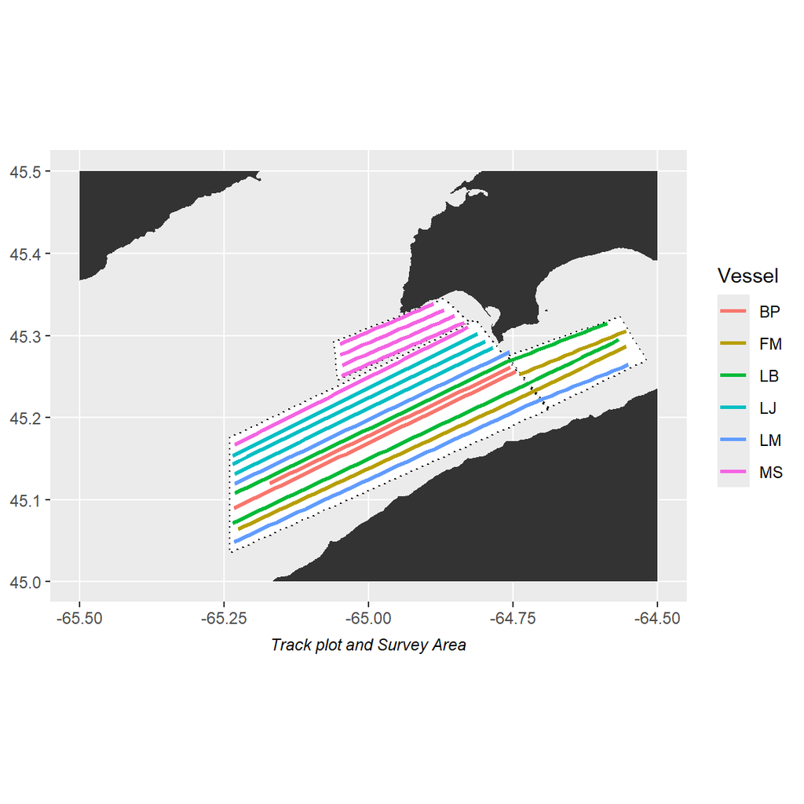

6 commercial purse seiners conducted this fishing survey on 21/06/2026 starting at 19:00:00, which was 0.93 hour after high tide.

There was a plankton tow and replicate conducted and CTD cast by Lady Melissa.

No tags were applied during this survey.

Samples were obtained for target strength estimation.

### Tides Tables

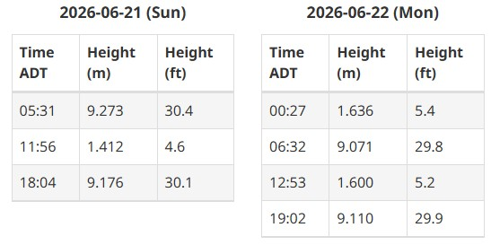

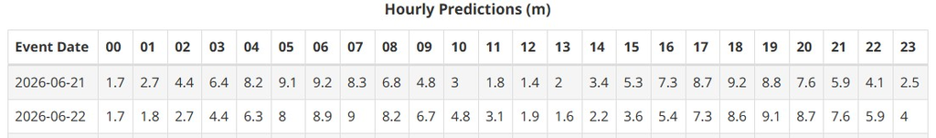

Tide Schedule for Margaretsville NS, Station #315m Source: www.waterlevels.gc.ca

### Acoustic Equipment

Each vessel was equipped with a Simrad ES38-18/200-18C combi (2-in-1) transducer prior to the survey that contains a 38kHz split beam and 200 kHz single beam transducer. Data was logged to the computer hard-drive for post-processing. All participating boats were calibrated on 38kHz before the survey.

## Survey Results

### Main Results

The results are subject to change as DFO will re-evaluate data editing, area estimation and apply a target strength.

**Preliminary biomass prediction for Scots Bay using standardized parallel transects is 44,195mt, and with turnover applied 25,125mt.**

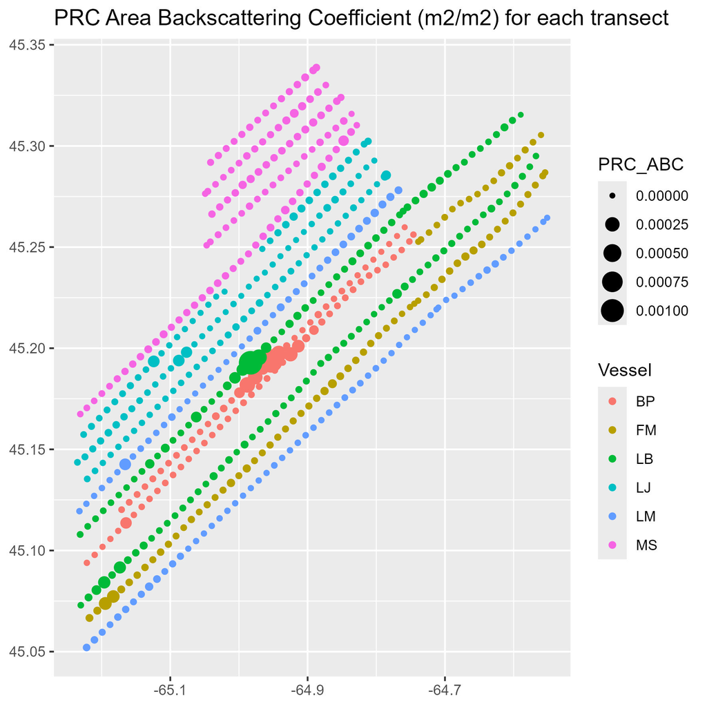

### Transect Details

Table 1: Transect Details

| Vessel | Transect # | Date/Time Start | Date/Time End | Start Lon | Start Lat | End Lon | End Lat | Location | Distance (km) | Speed |
| --- | --- | --- | --- | --- | --- | --- | --- | --- | --- | --- |
| BP | T01 | 2026-06-21 18:30:06 | 2026-06-21 21:33:24 | -65.233 | 45.090 | -64.746 | 45.256 | SB | 42.60 | 7.53 |
| BP | T02 | 2026-06-21 21:36:29 | 2026-06-21 23:36:55 | -64.755 | 45.261 | -65.171 | 45.120 | SB | 36.31 | 9.77 |
| FM | T01 | 2026-06-21 19:54:13 | 2026-06-21 23:04:18 | -65.226 | 45.064 | -64.745 | 45.222 | SB | 42.26 | 7.20 |
| FM | T02 | 2026-06-21 23:04:19 | 2026-06-22 00:13:33 | -64.745 | 45.222 | -64.554 | 45.287 | SB | 16.79 | 7.86 |
| FM | T03 | 2026-06-22 00:19:52 | 2026-06-22 01:22:20 | -64.555 | 45.306 | -64.739 | 45.253 | SB | 15.74 | 8.16 |
| LB | T01 | 2026-06-21 18:28:19 | 2026-06-21 22:21:57 | -65.236 | 45.071 | -64.737 | 45.238 | SB | 44.47 | 6.17 |
| LB | T04 | 2026-06-22 00:33:54 | 2026-06-22 03:25:33 | -64.761 | 45.268 | -65.231 | 45.108 | SB | 41.46 | 7.82 |
| LB | T02 | 2026-06-21 22:21:55 | 2026-06-21 23:35:32 | -64.737 | 45.238 | -64.567 | 45.295 | SB | 14.97 | 6.59 |
| LB | T03 | 2026-06-21 23:44:38 | 2026-06-22 00:33:55 | -64.588 | 45.315 | -64.761 | 45.268 | SB | 14.69 | 9.65 |
| LJ | T01 | 2026-06-21 18:49:12 | 2026-06-21 21:41:21 | -65.232 | 45.131 | -64.785 | 45.286 | SB | 39.18 | 7.37 |
| LJ | T02 | 2026-06-21 21:46:20 | 2026-06-22 00:13:31 | -64.799 | 45.293 | -65.235 | 45.144 | SB | 38.25 | 8.42 |
| LJ | T03 | 2026-06-22 00:17:51 | 2026-06-22 02:40:47 | -65.236 | 45.153 | -64.812 | 45.302 | SB | 37.39 | 8.48 |
| LM | T01 | 2026-06-21 18:47:59 | 2026-06-21 22:02:55 | -65.233 | 45.048 | -64.712 | 45.219 | SB | 45.74 | 7.60 |
| LM | T03 | 2026-06-21 23:42:43 | 2026-06-22 02:28:47 | -64.756 | 45.280 | -65.232 | 45.119 | SB | 41.84 | 8.16 |
| LM | T02 | 2026-06-21 22:02:57 | 2026-06-21 22:54:05 | -64.712 | 45.219 | -64.551 | 45.264 | SB | 13.73 | 8.70 |
| MS | T01 | 2026-06-21 19:42:53 | 2026-06-21 22:06:54 | -65.232 | 45.167 | -64.828 | 45.310 | SB | 36.88 | 8.30 |
| MS | T02 | 2026-06-21 22:10:29 | 2026-06-21 23:17:29 | -64.835 | 45.316 | -65.047 | 45.251 | SB | 18.56 | 8.97 |
| MS | T03 | 2026-06-21 23:24:23 | 2026-06-22 00:31:10 | -65.046 | 45.264 | -64.851 | 45.324 | SB | 17.12 | 8.31 |
| MS | T04 | 2026-06-22 00:38:54 | 2026-06-22 01:35:16 | -64.869 | 45.331 | -65.049 | 45.276 | SB | 15.70 | 9.02 |
| MS | T05 | 2026-06-22 01:42:01 | 2026-06-22 02:31:36 | -65.050 | 45.290 | -64.887 | 45.339 | SB | 14.15 | 9.24 |

### Survey Summary

Table 2: Acoustic Survey Results

| Vessel | Transect No. | Target Strength (db/kg) | Mean Sa (/m2) | Biomass Density (kg/m2) |
| --- | --- | --- | --- | --- |
| BP | T02 | -35.5 | -41.259 | 0.266 |
| LB | T04 | -35.5 | -42.930 | 0.181 |
| BP | T01 | -35.5 | -48.358 | 0.052 |
| FM | T01 | -35.5 | -48.471 | 0.050 |
| MS | T03 | -35.5 | -49.361 | 0.041 |
| LB | T01 | -35.5 | -49.381 | 0.041 |
| MS | T01 | -35.5 | -50.137 | 0.034 |
| LB | T03 | -35.5 | -50.161 | 0.034 |
| MS | T04 | -35.5 | -50.507 | 0.032 |
| LJ | T02 | -35.5 | -50.881 | 0.029 |
| LJ | T03 | -35.5 | -50.909 | 0.029 |
| LM | T03 | -35.5 | -51.296 | 0.026 |
| FM | T02 | -35.5 | -51.408 | 0.026 |
| MS | T05 | -35.5 | -51.856 | 0.023 |
| LB | T02 | -35.5 | -53.721 | 0.015 |
| MS | T02 | -35.5 | -54.360 | 0.013 |
| LJ | T01 | -35.5 | -54.825 | 0.012 |
| LM | T01 | -35.5 | -55.218 | 0.011 |
| FM | T03 | -35.5 | -55.391 | 0.010 |
| LM | T02 | -35.5 | -56.620 | 0.008 |

Note:  
Transects are listed from greatest to least backscatter.

Table 3: Survey Summary Table

| Layer | Target Strength | Area (km2) | Mean Sa | Density (kg/m2) | Biomass (tons) | Percent Area | Percent Biomass | Standard Error (tons) | Standard Error (%) |
| --- | --- | --- | --- | --- | --- | --- | --- | --- | --- |
| Main Box | -35.5 | 616.61710 | -47.4046 | 0.0664 | 39,770.023 | 75.5 | 90.0 | 15,033.58 | 37.80 |
| Northern Box | -35.5 | 80.94466 | -51.1888 | 0.0272 | 2,184.274 | 9.9 | 4.9 | 484.86 | 22.20 |
| Eastern Box | -35.5 | 119.32150 | -52.7626 | 0.0186 | 2,241.105 | 14.6 | 5.1 | 592.60 | 26.44 |

### Greatest Biomass Densities

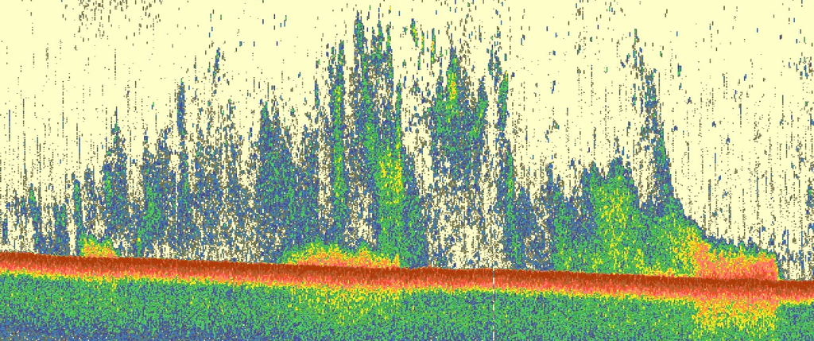

A snip from the transect with the greatest biomass density (kg/m2)

The single point with the largest biomass density (kg/m2) was recorded by **LB**, at the following location:

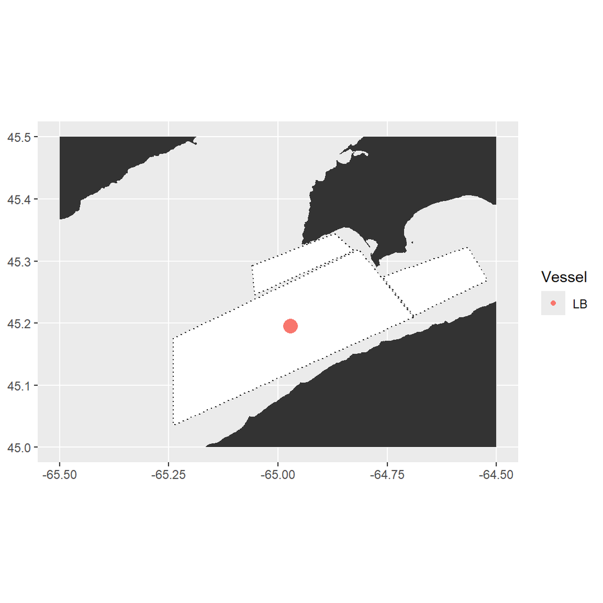

The transect with the greatest average biomass density (kg/m2) was recorded by **BP**, at the following location:

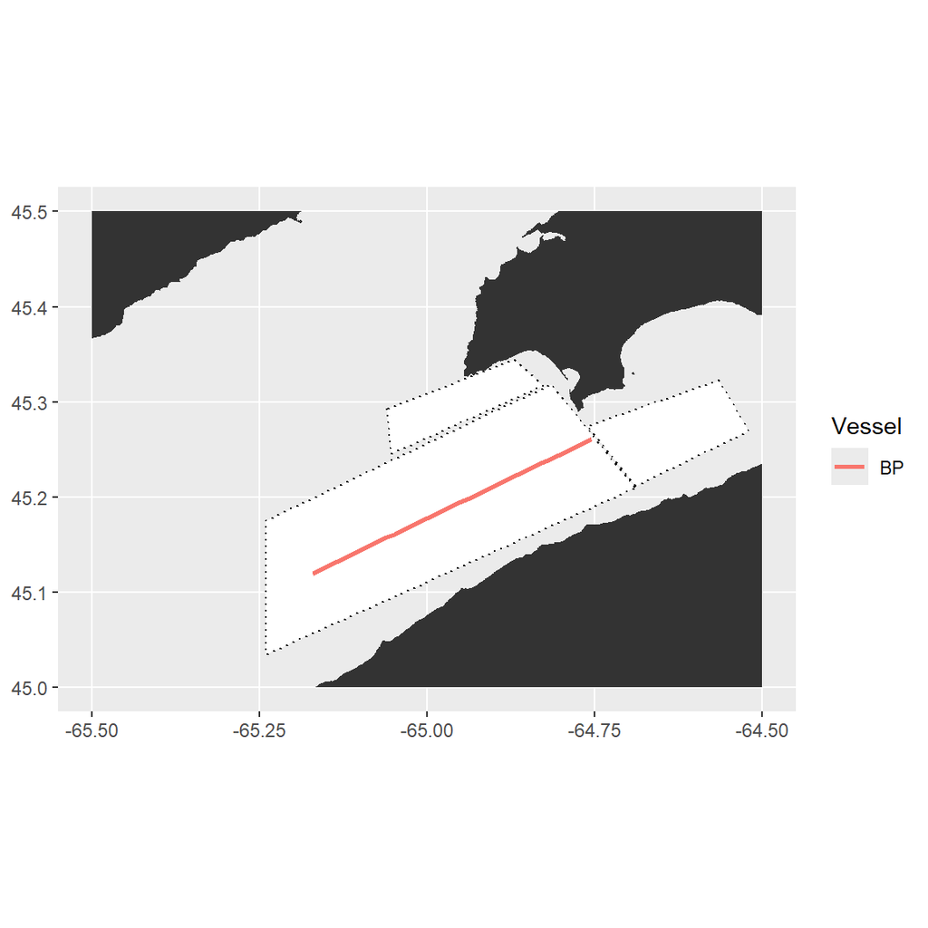

### Annual Summaries

This table does not include the biomass from adhoc surveys.

Table 4: Annual Comparison Table

| Ground | Survey Number | Current Year Survey Date | Current Year HSC Estimate | Current Year HSC Turnover Adjusted | Previous Year Survey Date | Previous Year HSC Estimate | Previous Year HSC Turnover Adjusted | Previous Year DFO Estimate | Previous Year DFO Turnover Adjusted |
| --- | --- | --- | --- | --- | --- | --- | --- | --- | --- |
| Scots Bay | 1 | 2026-05-10 | 29,384.44 | 29,384.44 | 2025-05-06 | 12,306.000 | 12,306 | NA | NA |
| Scots Bay | 2 | 2026-05-24 | 61,137.92 | 57,168.56 | 2025-05-21 | 120,045.000 | 118,023 | NA | NA |
| Scots Bay | 3 | 2026-06-07 | 48,291.49 | 35,960.00 | 2025-06-03 | 123,037.000 | 109,821 | NA | NA |
| Scots Bay | 4 | 2026-06-21 | 44,195.40 | 25,125.15 | 2025-06-16 | 14,184.000 | 0 | NA | NA |
| Scots Bay | 5 | NA | NA | NA | 2025-06-30 | 15,789.000 | 11,509 | NA | NA |
| Scots Bay | 6 | NA | NA | NA | 2025-07-14 | 7,114.000 | 5,137 | NA | NA |
| Scots Bay | 7 | NA | NA | NA | 2025-07-28 | 7,573.000 | 6,612 | NA | NA |
| Scots Bay | 8 | NA | NA | NA | 2025-08-11 | 5,164.476 | 4,916 | NA | NA |
| Scots Bay | 9 | NA | NA | NA | 2025-08-26 | 6,675.466 | 5,948 | NA | NA |
| Scots Bay | 10 | NA | NA | NA | 2025-09-08 | 4,180.432 | 3,169 | NA | NA |
| Scots Bay | 11 | NA | NA | NA | 2025-09-21 | 11,200.647 | 10,471 | NA | NA |

Table 5: Annual Summary Table

| Year | Ground | HSC Estimate | HSC Turnover Adjusted | DFO Estimate | DFO Turnover Adjusted |
| --- | --- | --- | --- | --- | --- |
| 2025 | Scots Bay | 327,269.0 | 287,912.0 | NA | NA |
| 2026 | Scots Bay | 183,009.2 | 147,638.2 | NA | NA |

## Vessel Performance

### Speed

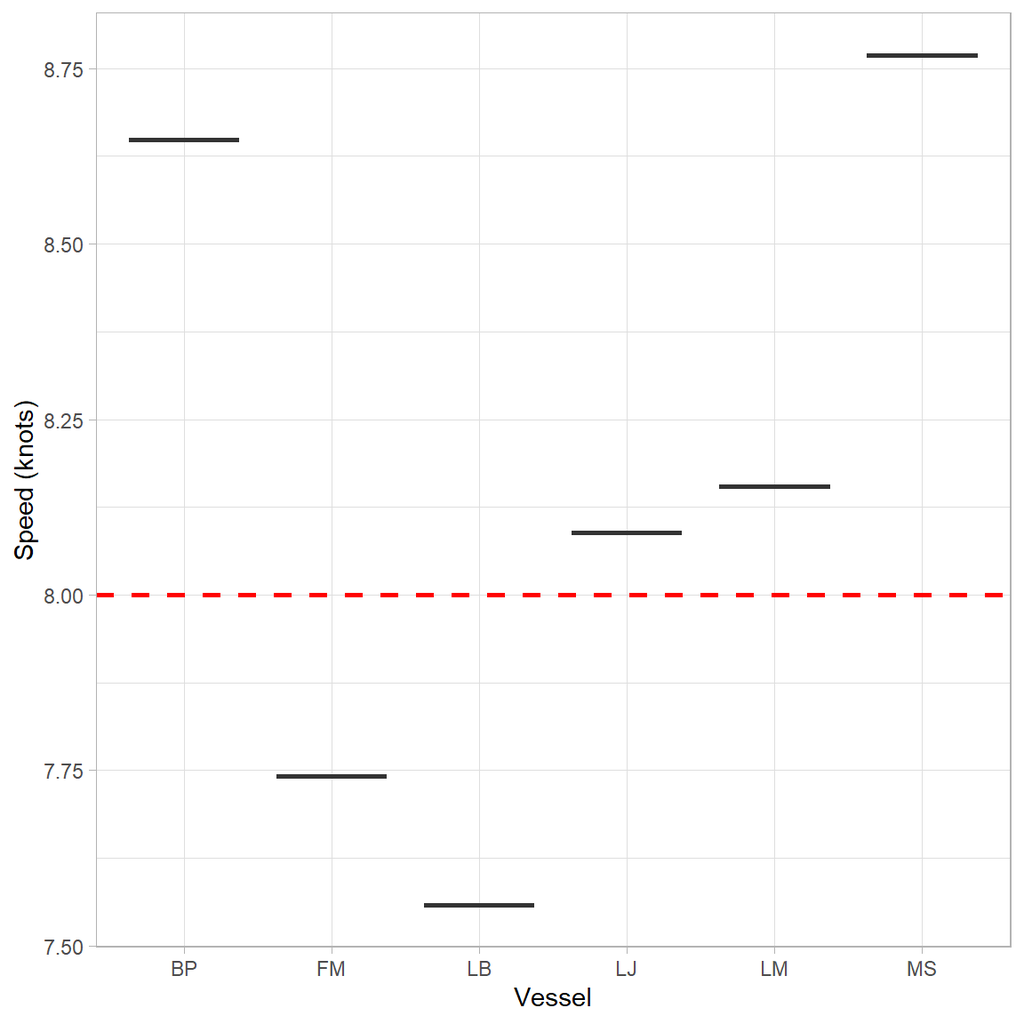

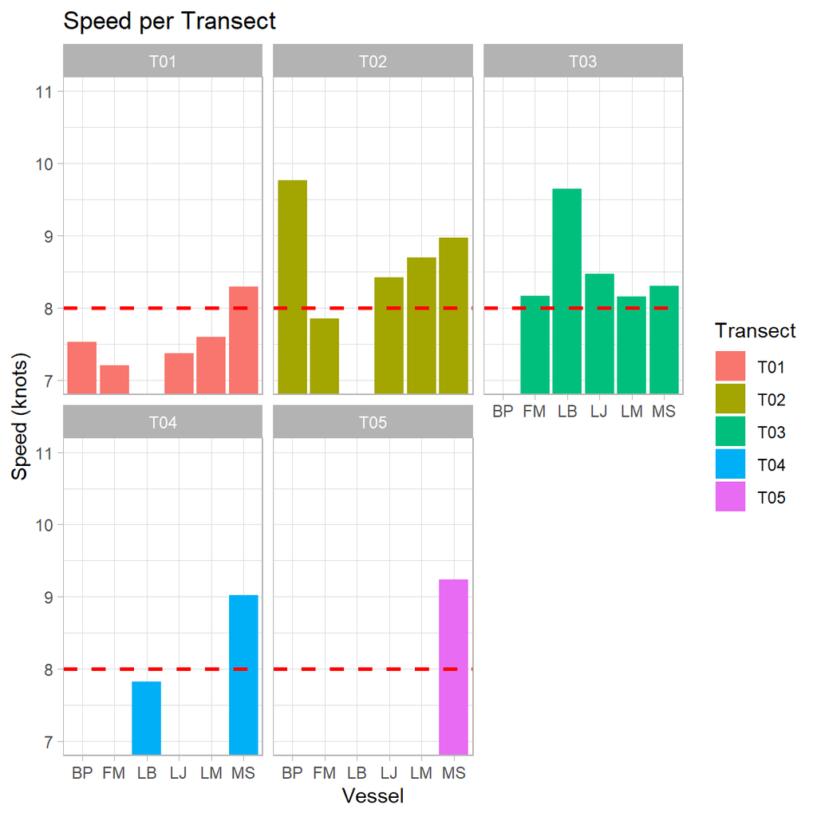

Average vessel speed was 8.16. This is above the 8 knot requirement; vessels are urged to slow down to prevent backscatter noise from interfering with the acoustic data.

The speed for each transect are rudimentary and are calculated based on distance. If a significant amount of distance is cut, the speed will appear slower.

### Distance

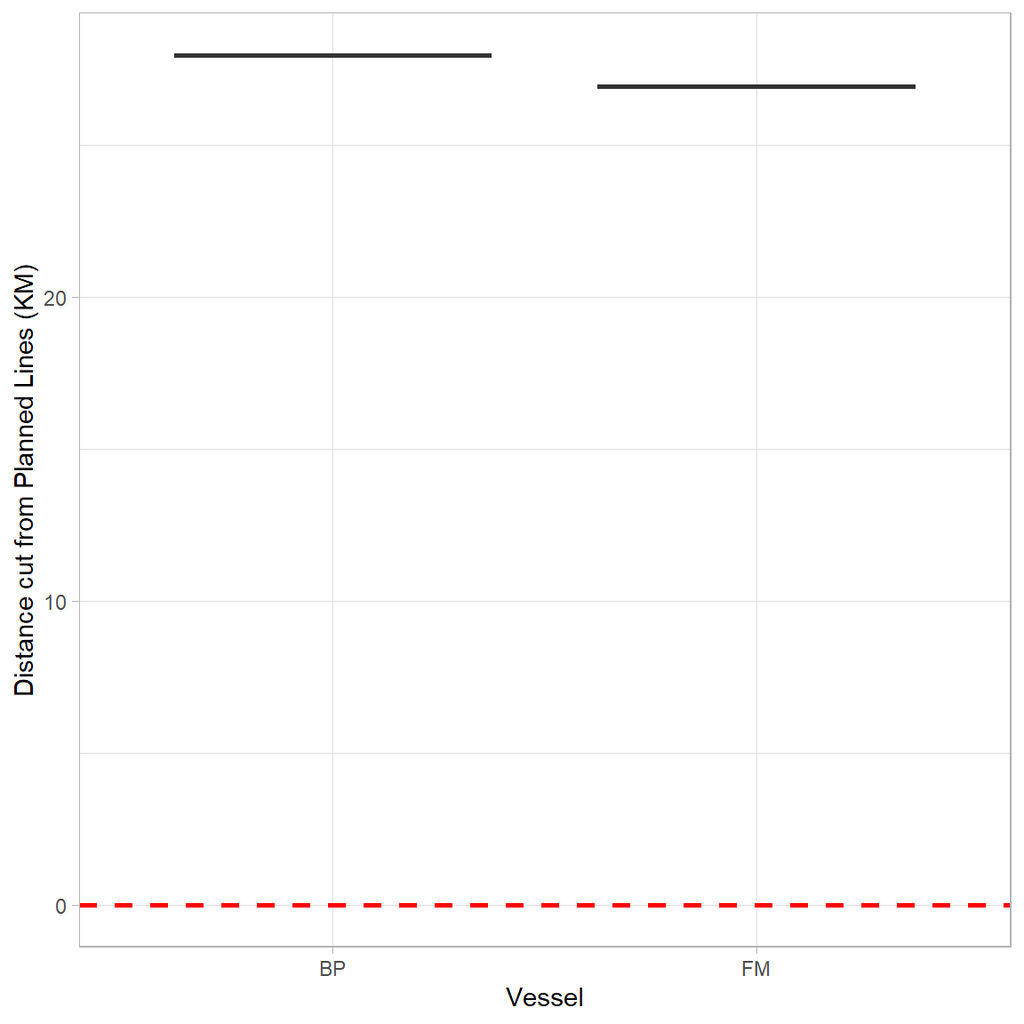

More than 2km of distance was cut from the planned lines; vessels are reminded to complete their assigned lines straight and without deviating or cutting corners short.